# Documentation: Optimal breeding value prediction using a Sparse Selection Index

Marco Lopez-Cruz<sup>1</sup>, and Gustavo de los Campos<sup>2,3,4,$\star$</sup>

<sup>1</sup>Department of Plant, Soil and Microbial Sciences, Michigan State University, USA.<sup>2</sup>Department of Epidemiology and Biostatistics, Michigan State University, USA.<sup>3</sup>Department of Statistics and Probability, Michigan State University, USA.<sup>4</sup>Institute for Quantitative Health Science and Engineering, Michigan State University, USA.<sup>$\star$</sup>Corresponding author (gustavoc@msu.edu)

# Standard Selection Index

Recall the basic **genetic model** that decomposes phenotypic observations, $\boldsymbol{y}=(y_1,…,y_n)'$, as the sum of breeding values, $\boldsymbol{u}=(u_1,…,u_n)'$, and environmental deviations, $\boldsymbol{\varepsilon}=(\varepsilon_1,…,\varepsilon_n)'$, as

$$\begin{equation*}
y_i=u_i+\varepsilon_i
\end{equation*}$$

Both $\boldsymbol{u}$ and $\boldsymbol{e}$ are assumed to have null means and $\text{var}(\boldsymbol{u})=\sigma_u^2 \textbf{G}$, $\text{var}(\boldsymbol{\varepsilon})=\sigma_\varepsilon^2 \textbf{I}$, and $\text{cov}(\boldsymbol{u},\boldsymbol{\varepsilon}')=\textbf{0}$, where $\sigma_u^2$ and $\sigma_\varepsilon^2$ are the common genetic and residual variances, respectively; $\textbf{G}$ is the **genetic relationship matrix** and $\textbf{I}$ is an identity matrix.

A standard **selection index** (SI) predicts the breeding value of an individual ($u_i$) using a linear combination of the training phenotypes:

$$\begin{equation*}
\mathcal{I}_i=\boldsymbol{\beta}'_i\boldsymbol{y}
\end{equation*}$$

where $\boldsymbol{\beta}_i=\{\beta_{ij}\}$ is a vector of weights which are obtained as the solution to the following optimization problem:

$$\begin{equation*}
\hat{\boldsymbol{\beta}}_i = \underset{\boldsymbol{\beta}_i}{\text{arg
min}}\frac{1}{2}\mathbb{E}\left(u_i-\boldsymbol{\beta}'_i\boldsymbol{y}\right)^2
\end{equation*}$$

This optimization problem can be reduced to

$$\begin{equation*}
\hat{\boldsymbol{\beta}}_i = \underset{\boldsymbol{\beta}_i}{\text{arg
min}}\left[\frac{1}{2}\boldsymbol{\beta}'_i(\textbf{G}+\theta
\textbf{I})\boldsymbol{\beta}_i -
\textbf{G}'_i\boldsymbol{\beta}_i\right]
\end{equation*}$$

where $\theta=\sigma_\varepsilon^2/\sigma_u^2=(1-h^2)/h^2$ is the ratio of the residual to the genetic variance, which can be expressed in terms of the **heritability**, $h^2$. The solution to the above problem can be shown to be

$$\begin{equation*}
\hat{\boldsymbol{\beta}}_i = (\textbf{G}+\theta
\textbf{I})^{-1}\textbf{G}_i
\end{equation*}$$

The vector $\hat{\boldsymbol{\beta}}_i$ can be shown to be the $i^{th}$ row of the Hat matrix of the **BLUPs of the genetic values** of the individuals in the prediction set, thus, depending on whether $\textbf{G}$ is a pedigree- or genomic-derived relationship matrix, the standard SI is equivalent to a **pedigree-** (Henderson 1963) or **genomic-BLUP**, respectively.

# Sparse Selection Index (SSI)

Sparsity (and possibly differential shrinkage on the $\hat{\boldsymbol{\beta}}_i$) can be achieved by adding an L1-penalty to the above optimization function; therefore,

$$\begin{equation*}
\tilde{\boldsymbol{\beta}}_i = \underset{\boldsymbol{\beta}_i}{\text{arg
min}}\left[\frac{1}{2}\boldsymbol{\beta}'_i(\textbf{G}+\theta
\textbf{I})\boldsymbol{\beta}_i - \textbf{G}'_i\boldsymbol{\beta}_i
+ \lambda\sum_{j=1}^n|\beta_{ij}|\right]
\end{equation*}$$

The above optimization problem does not have a closed-form solution; however, solutions can be obtained using a Coordinate Descent algorithm very similar to the one used to solve LASSO problems (Lopez-Cruz et al. 2020). The value $\lambda=0$ produces the coefficients of the standard SI (or G-BLUP).

The regularization parameter $\lambda$ controls how sparse $\tilde{\boldsymbol{\beta}}_i$ will be; this parameter is also expected to affect the accuracy of the index. Therefore, an optimal value of $\lambda$ can be found by maximizing the accuracy of the resulting index.

# Genetic analysis

To quantify the **prediction accuracy** of each of the indices, we randomly divide data set into training (trn) and testing (tst) sets. Predictions were derived by first obtaining $\hat{\boldsymbol{\beta}}_i$ for the standard SI and $\tilde{\boldsymbol{\beta}}_i(\lambda)$ for the SSI. These coeficicients are obtained using training data, i.e., with $\textbf{G}=\textbf{G}_{trn}$ representing the genomic matrix of the training data points, and $\textbf{G}_i=\textbf{G}_{trn,tst(i)}$ being the vector containing the genomic relationships between the $i^{th}$ data-point of the testing set, with each of the individuals assigned to the training set. This is repeated for each individual in the testing set ($i=1,...,n_{tst}$). Subsequently, predictions for each individual are obtained using $\hat{\mathcal{I}}_i=\hat{\boldsymbol{\beta}}'_i \boldsymbol{y}_{trn}$ (for the standard SI) and $\hat{\mathcal{I}}_i(\lambda)=\tilde{\boldsymbol{\beta}}'_i(\lambda) \boldsymbol{y}_{trn}$ (for the SSI) where $\boldsymbol{y}_{trn}$ is a $n_{trn}\times 1$ vector with the adjusted-centered phenotypes of the training set.

The implementation of the SI requires **heritability estimates**. These are derived by fitting a G-BLUP model as above-mentioned within the training set, i.e., using $\boldsymbol{y}_{trn}$ and $\textbf{G}_{trn}$. We then use the variance parameters estimates to derive $h^2=\sigma_u^2/(\sigma_u^2 + \sigma_\varepsilon^2 )$.

**Prediction accuracy** ($\rho$) is measured with the correlation between the phenotype and the index, divided by the square-root of the heritability of the trait, $\rho=Acc(\mathcal{I})=Cor(\hat{\mathcal{I}}_i,y_i )/h$ (Dekkers 2007). We apply all methods to the same training-testing partitions and report, from these analyses, the average prediction accuracy and the proportion of times that one method is better than the other.

To determine an **optimal value of** $\boldsymbol{\lambda}$ we implement a calibration analysis using data from the training data only. Specifically, for each training set, we conduct an internal **cross-validation** (CV) as follows: (i) The training data set is partitioned into $k$ subsets. (ii) SSIs are derived over a grid of values of $\lambda$ using data from $k-1$ folds for training and the data in the $k^{th}$ fold as testing. (iii) The resulting curves profiling accuracy ($\rho$) by values of $\lambda$ are used to identify the value of $\lambda$ ($\hat{\lambda}_{cv}$) that maximizes accuracy. (iv) Finally, we use all the data from the training set to derive $\mathcal{I}_i (\hat{\lambda}_{cv})$ and evaluated the accuracy of the resulting index in the left-out data from the testing set.

# Implementation

To illustrate how to fit Sparse Selection Indices for grain yield, we use data from the Wheat-small data set which is available with the [BGLR](https://github.com/gdlc/BGLR-R) R-package (Perez and Campos 2014). Sparse Selection Indices will be derived using the SFSI R-package (Lopez-Cruz et al. 2020).

## Data preparation

The following code shows how to prepare data for environment 1; all the analyses hereinafter are based on this data.

```r
library(SFSI)
if(requireNamespace("BGLR")){
 data(wheat, package="BGLR")     # Load data from the BGLR package
}

# Select the environment 1 to work with
y <- as.vector(scale(wheat.Y[,1]))

# Calculate G matrix
G <- tcrossprod(scale(wheat.X))/ncol(wheat.X)

# Save data
save(y, G, file="geno_pheno.RData")
```

## Heritability and variance components

Implementing the SSI requires an estimate of the heritability. We obtain this using a G-BLUP model $y_i=\mu+u_i+\varepsilon_i$ with $\varepsilon_i \overset{iid}{\sim} N(0,\sigma_\varepsilon^2)$ and $\boldsymbol{u}\sim N(\textbf{0},\sigma_u^2 \boldsymbol{G})$. This model can be fitted with the function `fitBLUP` included in the SFSI R-package. The BGLR R-package can be also used to fit a Bayesian version of the model. The code below illustrates how to estimate heritability using the function `fitBLUP`.

```r
load("geno_pheno.RData") # Load data

# Fit model
fm0 <- fitBLUP(y, K=G)
fm0$theta <- fm0$varE/fm0$varU          # Residual/genetic variances ratio
fm0$h2 <- fm0$varU/(fm0$varU+fm0$varE)  # Heritability
c(fm0$varU,fm0$varE,fm0$theta,fm0$h2)   # Print variance components

save(fm0, file="varComps.RData")
```

## Training-testing partitions

The code below produces training (trn, $70\%$) and testing (tst, $30\%$) partitions. The parameter `nPart` defines the number of partitions. The output is a matrix with `nPart` columns containing 1’s and 0’s indexing the observations that are assigned to the training and testing sets, respectively. The object is saved in the file `partitions.RData` and will be used in later analyses.

```r
nPart <- 5                        # Number of partitions
load("geno_pheno.RData")          # Load data

nTST <- ceiling(0.3*length(y))    # Number of elements in TST set
partitions <- matrix(1,nrow=length(y),ncol=nPart)   # Matrix to store partitions
seeds <- round(seq(1E3, .Machine$integer.max/10, length=nPart))

for(k in 1:nPart)
{   set.seed(seeds[k])
    partitions[sample(1:length(y), nTST),k] <- 0
}
save(partitions, file="partitions.RData")    # Save partitions
```

## Accuracy of the G-BLUP and of the Sparse SI

The following script shows how to derive SSIs using the partitions above created. The weights of the SSI are computed using the function `SSI` for `nLambda=100` values of $\lambda$. The G-BLUP model is fitted for comparison using the function `fitBLUP`. Estimates of $\mu$ and $h^2$ are computed internally in the function `SSI` when these are not provided. These estimates obtained from the G-BLUP model will be passed to the function `SSI` to save time. Indices denoting training and testing sets are passed through the `trn` and `tst` arguments, respectively. The accuracy of the G-BLUP and SSI models are stored in the object `accSSI`, and saved in the file `results_accuracy.RData`.

```r
# Load data
load("geno_pheno.RData"); load("varComps.RData"); load("partitions.RData")

accSSI <- mu <- varU <- varE <- c()       # Objects to store results

for(k in 1:ncol(partitions))
{ cat("  partition = ",k,"\n")
  trn_tst <- partitions[,k]
  tst <- which(trn_tst==0)
  yNA <- y;   yNA[tst] <- NA

  # G-BLUP model
  fm1 <- fitBLUP(yNA, K=G)
  mu[k] <- fm1$b        # Retrieve mu estimate
  varU[k] <- fm1$varU   # Retrieve varU
  varE[k] <- fm1$varE   # Retrieve varE

  # Sparse SI
  fm2 <- SSI(y,K=G,b=mu[k],varU=varU[k],varE=varE[k],trn_tst=trn_tst,mc.cores=1,nlambda=100)
  fm3 <- summary(fm2)   # Useful function to get results

  accuracy <- c(GBLUP=cor(fm1$yHat[tst],y[tst]), fm3$accuracy[,1])/sqrt(fm0$h2)
  lambda <- c(min(fm3$lambda),fm3$lambda[,1])
  nsup <- c(max(fm3$nsup),fm3$nsup[,1])
  accSSI <- rbind(accSSI,data.frame(rep=k,SSI=names(accuracy),accuracy,lambda,nsup))
}
save(mu,varU,varE,accSSI,file="results_accuracy.RData")
```

## Displaying Results

The following code creates a plot showing the estimated genetic prediction accuracy by values of the penalty parameter (in logarithmic scale). The rightmost point in the plot corresponds to the G-BLUP model (obtained when $\lambda=0$). The point at the peak denotes the maximum accuracy (in the testing set) that was obtained by the SSI.

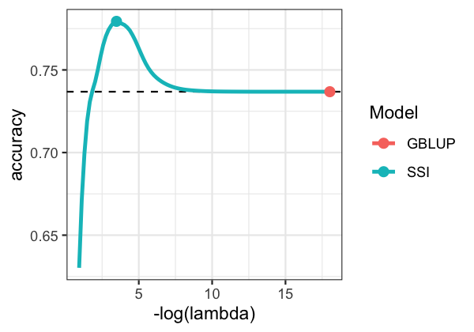

Figure. Effect of the penalization on the accuracy

```r
load("results_accuracy.RData")

dat <- data.frame(do.call(rbind,lapply(split(accSSI,accSSI$SSI),
         function(x) apply(x[,-c(1:2)],2,mean))))
dat$Model <- unlist(lapply(strsplit(rownames(dat),"\\."),function(x)x[1]))

dat2 <- do.call(rbind,lapply(split(dat,dat$Mod),function(x)x[which.max(x$acc),]))

if(requireNamespace("ggplot2")){
 ggplot2::ggplot(dat[dat$nsup>1,],ggplot2::aes(-log(lambda),accuracy)) +
   ggplot2::geom_hline(yintercept=dat["GBLUP",]$accuracy, linetype="dashed") +
   ggplot2::geom_line(ggplot2::aes(color=Model),size=1.1) + ggplot2::theme_bw() +
   ggplot2::geom_point(data=dat2,ggplot2::aes(color=Model),size=2.5)
}
```

## Cross-validating to obtain an optimal penalization

The snippet below can be used to perform, within each trn-tst partition, $k$-folds CV to get an ‘optimal’ value of $\lambda$ within the training data, and then used to fit an SSI for the testing set. The CV is implemented using the function `SSI.CV` from the SFSI R-package for one 5-folds CV, this can be set by changing the `nCV` and `nfolds` arguments.

```r
load("geno_pheno.RData");   load("varComps.RData")
load("partitions.RData");   load("results_accuracy.RData")

lambdaCV <- accSSI_CV <- nsupCV <- c()   # Objects to store results

for(k in 1:ncol(partitions))
{   cat("  partition = ",k,"\n")
    trn_tst <- partitions[,k]

    # Cross-validating the training set
    fm1 <- SSI.CV(y,K=G,trn_tst=trn_tst,nlambda=100,mc.cores=1,nfolds=5,nCV=1)
    lambdaCV[k] <- summary(fm1)$optCOR["lambda"]

    # Fit a SSI with the estimated lambda
    fm2 <- SSI(y,K=G,b=mu[k],varU=varU[k],varE=varE[k],trn_tst=trn_tst,lambda=lambdaCV[k])

    accSSI_CV[k] <- summary(fm2)$accuracy/sqrt(fm0$h2)
    nsupCV <- cbind(nsupCV, fm2$nsup)
}
save(accSSI_CV,lambdaCV,nsupCV,file="results_accuracyCV.RData")
```

After running the above analysis, the following snippet can be run to create a plot comparing partition-wise the accuracy of the optimal SSI with that of the G-BLUP. The average accuracies are also shown in the plot.

[figure not shown]

Figure. Accuracy of the G-BLUP vs. that of the SSI

```r
load("results_accuracy.RData"); load("results_accuracyCV.RData")

dat <- data.frame(GBLUP=accSSI[accSSI$SSI=="GBLUP",]$acc,SSI=accSSI_CV)
rg <- range(dat)
tmp <- c(mean(rg),diff(rg)*0.4)

if(requireNamespace("ggplot2")){
 ggplot2::ggplot(dat,ggplot2::aes(GBLUP,SSI)) +
  ggplot2::geom_abline(slope=1,linetype="dotted") + ggplot2::theme_bw() +
  ggplot2::geom_point(shape=21,color="orange") + ggplot2::lims(x=rg,y=rg) +
  ggplot2::annotate("text",tmp[1],tmp[1]-tmp[2],label=round(mean(dat$GBLUP),3)) +
  ggplot2::annotate("text",tmp[1]-tmp[2],tmp[1],label=round(mean(dat$SSI),3))
}
```

The code below creates a plot showing the distribution of the number of points in the support set for the SSI, across all partitions.

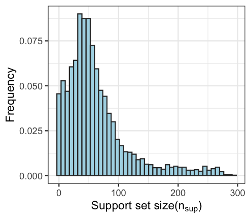

Figure. Distribution of the number of support points

```r
load("results_accuracyCV.RData")

dat <- data.frame(nsup=as.vector(nsupCV))

bw <- round(diff(range(dat$nsup))/40)
if(requireNamespace("ggplot2")){
 ggplot2::ggplot(data=dat,ggplot2::aes(nsup,stat(count)/length(nsupCV))) +
    ggplot2::theme_bw() +
    ggplot2::geom_histogram(color="gray20",fill="lightblue",binwidth=bw) +
    ggplot2::labs(x=bquote("Support set size(" *n[sup]*")"),y="Frequency")
}
```

## Subject-specific training sets

The next script can be used to create a plot showing (for a single trn-tst partition) the subset of points in the support set, for each individual being predicted. This plot can be made through the function `net.plot` from the SFSI package.

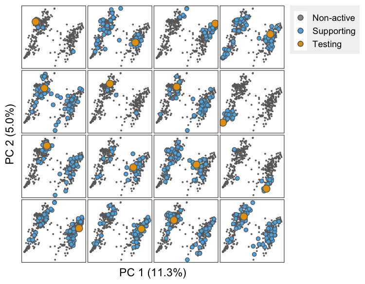

Figure. Subject specific trainig sets for the first 16 testing elements

```r
# Load data
load("geno_pheno.RData"); load("partitions.RData"); load("results_accuracyCV.RData")

part <- 1      # Choose any partition from 1,…,nPart
trn_tst <- partitions[,part]

# Fit SSI with lambda previously estimated using CV
fm <- SSI(y,K=G,trn_tst=trn_tst,lambda=lambdaCV[part])

plot(net(fm, K=G), i=1:16, unified=FALSE, main=NULL, bg.col="white",
     set.size=c(3,1.5,0.2), point.color="gray40", axis.labels=FALSE)
```

# References

Dekkers, J C M. 2007. “Prediction of response to marker-assisted and genomic selection using selection index theory.” *Journal of Animal Breeding and Genetics* 124: 331–41.

Henderson, C R. 1963. “Selection index and expected genetic advance.” In *Statistical Genetics and Plant Breeding: A Symposium and Workshop*, 141–63. Washington, D.C.: National Academy of Sciences-National Research Council.

Lopez-Cruz, Marco, Eric Olson, Gabriel Rovere, Jose Crossa, Susanne Dreisigacker, Mondal Suchismita, Ravi Singh, and Gustavo de los Campos. 2020. “Regularized selection indices for breeding value prediction using hyper-spectral image data.” *Scientific Reports* 10 (8195).

Perez, Paulino, and Gustavo de los Campos. 2014. “Genome-wide regression and prediction with the BGLR statistical package.” *Genetics* 198 (2): 483–95.